```python
import pandas as pd
import numpy as np
%matplotlib inline
import matplotlib.pyplot as plt
import seaborn as sns
#from pydataset import data
from scipy.stats import chi2
from scipy.stats import chi2_contingency
from CHAID import Tree
from scipy.cluster.hierarchy import dendrogram
import xlwt
from sklearn.preprocessing import LabelEncoder
from sklearn.feature_extraction import DictVectorizer
from sklearn import preprocessing
from sklearn.tree import DecisionTreeClassifier
from sklearn import tree
import pandas_profiling
from sklearn.model_selection import train_test_split
```

```python
df = pd.read_csv('titanic.csv')
```

```python
df.head()
```

|  | Unnamed: 0 | class | age | sex | survived |
| --- | --- | --- | --- | --- | --- |
| 0 | 1 | 1st class | adults | man | yes |
| 1 | 2 | 1st class | adults | man | yes |
| 2 | 3 | 1st class | adults | man | yes |
| 3 | 4 | 1st class | adults | man | yes |
| 4 | 5 | 1st class | adults | man | yes |

```python
print('hay', str(len(df)), 'datos obtenidos.')
print('')
print('valores para class: ', df['class'].unique())
print('')
print('valores para age: ',df['age'].unique())
print('')
print('valores para sex: ',df['sex'].unique())
print('')
print('valores para survived: ',df['survived'].unique())
```

```
hay 1316 datos obtenidos.

valores para class:  ['1st class' '2nd class' '3rd class']

valores para age:  ['adults' 'child']

valores para sex:  ['man' 'women']

valores para survived:  ['yes' 'no']
```

```python
pd.crosstab(index=df['survived'],
            columns=[df['class'],df['age'],df['sex']],margins=True)
```

| class age sex survived | 1st class adults man | 1st class adults women | 1st class child man | 1st class child women | 2nd class adults man | 2nd class adults women | 2nd class child man | 2nd class child women | 3rd class adults man | 3rd class adults women | 3rd class child man | 3rd class child women | All |
| --- | --- | --- | --- | --- | --- | --- | --- | --- | --- | --- | --- | --- | --- |
| no | 118 | 4 | 0 | 0 | 154 | 13 | 0 | 0 | 387 | 89 | 35 | 17 | 817 |
| yes | 57 | 140 | 5 | 1 | 14 | 80 | 11 | 13 | 75 | 76 | 13 | 14 | 499 |
| All | 175 | 144 | 5 | 1 | 168 | 93 | 11 | 13 | 462 | 165 | 48 | 31 | 1316 |

Se realizó la tabla de contingencia con multiples variables

```python
def missing_values_table(df):
        mis_val = df.isnull().sum()
        mis_val_percent = 100 * df.isnull().sum()/len(df)
        mis_val_table = pd.concat([mis_val, mis_val_percent], axis=1)
        mis_val_table_ren_columns = mis_val_table.rename(
        columns = {0 : 'Missing Values', 1 : '% of Total Values'})
        return mis_val_table_ren_columns
```

**Se realiza tabla de contingencia con la variable clase y survived, mas la prueba de chi cuadrado**

```python
Tabla_clase = pd.crosstab(index=df['survived'],
            columns=[df['class']],margins=True)
Tabla_clase.index= ["yes","no","Total"]
Tabla_clase
```

[output not shown]

```python
chi2_contingency(Tabla_clase)
```

```
(133.05203598610018,
 2.9249941496115534e-26,
 6,
 array([[ 201.76671733,  176.93389058,  438.2993921 ,  817.        ],
        [ 123.23328267,  108.06610942,  267.7006079 ,  499.        ],
        [ 325.        ,  285.        ,  706.        , 1316.        ]]))
```

```python
print('Valor Chi-2', str(chi2_contingency(Tabla_clase)[0]), 'p-value', str(chi2_contingency(Tabla_clase)[1]))
```

```
Valor Chi-2 133.05203598610018 p-value 2.9249941496115534e-26
```

**Se realiza tabla de contingencia con la variable edad y survived, mas la prueba de chi cuadrado**

```python
Tabla_edad = pd.crosstab(index=df['survived'],
            columns=[df['age']],margins=True)
Tabla_edad.index= ["yes","no","Total"]
Tabla_edad
```

[output not shown]

```python
chi2_contingency(Tabla_edad)
```

```
(10.433234374362144,
 0.03372920198971611,
 4,
 array([[ 749.33054711,   67.66945289,  817.        ],
        [ 457.66945289,   41.33054711,  499.        ],
        [1207.        ,  109.        , 1316.        ]]))
```

```python
print('Valor Chi-2', str(chi2_contingency(Tabla_edad)[0]), 'p-value', str(chi2_contingency(Tabla_edad)[1]))
```

```
Valor Chi-2 10.433234374362144 p-value 0.03372920198971611
```

**Se realiza tabla de contingencia con la variable sex y survived, mas la prueba de chi cuadrado**

```python
Tabla_sexo = pd.crosstab(index=df['survived'],
            columns=[df['sex']],margins=True)
Tabla_sexo.index= ["yes","no","Total"]
Tabla_sexo
```

[output not shown]

```python
chi2_contingency(Tabla_sexo)
```

```
(343.5683748952206,
 4.291205455004174e-73,
 4,
 array([[ 539.49316109,  277.50683891,  817.        ],
        [ 329.50683891,  169.49316109,  499.        ],
        [ 869.        ,  447.        , 1316.        ]]))
```

```python
print('Valor Chi-2', str(chi2_contingency(Tabla_sexo)[0]), 'p-value', str(chi2_contingency(Tabla_sexo)[1]))
```

```
Valor Chi-2 343.5683748952206 p-value 4.291205455004174e-73
```

**La variable dependiente es la variable survived, y sus categorías son sí y no**

**Las variables independientes son sex, class y age. Para sex, las categorías son hombre, mujer, para class las categorías son 1era clase, 2da clase y 3ra clase. Por último, para age, las categorías son adulto y niño**

**Se realiza a continuación la misma prueba con la variable clase, pero esta vez sin tener en cuenta la primera clase**

```python
df_par1=df[df['class']!='1st class']
```

```python
Tabla_clase_1 = pd.crosstab(index=df_par1['survived'],
            columns=[df_par1['class']])
Tabla_clase_1.index= ["No","Sí"]
Tabla_clase_1
```

| class | 2nd class | 3rd class |
| --- | --- | --- |
| No | 167 | 528 |
| Sí | 118 | 178 |

```python
chi2_contingency(Tabla_clase_1)
```

```
(24.642455652387003,
 6.901440123134889e-07,
 1,
 array([[199.87386478, 495.12613522],
        [ 85.12613522, 210.87386478]]))
```

```python
print('Valor Chi-1', str(chi2_contingency(Tabla_clase_1)[0]), 'p-value', str(chi2_contingency(Tabla_clase_1)[1]))
```

```
Valor Chi-1 24.642455652387003 p-value 6.901440123134889e-07
```

```python
df_par2=df[df['class']!='2nd class']
```

```python
Tabla_clase_2 = pd.crosstab(index=df_par1['survived'],
            columns=[df_par2['class']])
Tabla_clase_2.index= ["No","Sí"]
Tabla_clase_2
```

| class | 3rd class |
| --- | --- |
| No | 528 |
| Sí | 178 |

```python
chi2_contingency(Tabla_clase_2)
```

```
(0.0, 1.0, 0, array([[528.],
        [178.]]))
```

```python
print('Valor Chi-1', str(chi2_contingency(Tabla_clase_2)[0]), 'p-value', str(chi2_contingency(Tabla_clase_2)[1]))
```

```
Valor Chi-1 0.0 p-value 1.0
```

```python
df_par3=df[df['class']!='3rd class']
```

```python
df_par3.head()
```

|  | Unnamed: 0 | class | age | sex | survived |
| --- | --- | --- | --- | --- | --- |
| 0 | 1 | 1st class | adults | man | yes |
| 1 | 2 | 1st class | adults | man | yes |
| 2 | 3 | 1st class | adults | man | yes |
| 3 | 4 | 1st class | adults | man | yes |
| 4 | 5 | 1st class | adults | man | yes |

```python
Tabla_clase_3 = pd.crosstab(index=df_par1['survived'],
            columns=[df_par3['class']])
Tabla_clase_3.index= ["No","Sí"]
Tabla_clase_3
```

| class | 2nd class |
| --- | --- |
| No | 167 |
| Sí | 118 |

```python
chi2_contingency(Tabla_clase_3)
```

```
(0.0, 1.0, 0, array([[167.],
        [118.]]))
```

```python
print('Valor Chi-1', str(chi2_contingency(Tabla_clase_3)[0]), 'p-value', str(chi2_contingency(Tabla_clase_3)[1]))
```

```
Valor Chi-1 0.0 p-value 1.0
```

```python
df2 = df.replace(to_replace=['1st class','2nd class'],value='1st-2nd class')
```

```python
df2.head()
```

|  | Unnamed: 0 | class | age | sex | survived |
| --- | --- | --- | --- | --- | --- |
| 0 | 1 | 1st-2nd class | adults | man | yes |
| 1 | 2 | 1st-2nd class | adults | man | yes |
| 2 | 3 | 1st-2nd class | adults | man | yes |
| 3 | 4 | 1st-2nd class | adults | man | yes |
| 4 | 5 | 1st-2nd class | adults | man | yes |

```python
Tabla_clase_4 = pd.crosstab(index=df2['survived'],
            columns=[df2['class']],margins=True)
Tabla_clase_4.index= ["No","Sí","Total"]
Tabla_clase_4
```

| class | 1st-2nd class | 3rd class | All |
| --- | --- | --- | --- |
| No | 289 | 528 | 817 |
| Sí | 321 | 178 | 499 |
| Total | 610 | 706 | 1316 |

```python
chi2_contingency(Tabla_clase_4)
```

```
(104.44828229154874,
 1.110330680653495e-21,
 4,
 array([[ 378.7006079,  438.2993921,  817.       ],
        [ 231.2993921,  267.7006079,  499.       ],
        [ 610.       ,  706.       , 1316.       ]]))
```

```python
print('Valor Chi-1', str(chi2_contingency(Tabla_clase_4)[0]), 'p-value', str(chi2_contingency(Tabla_clase_4)[1]))
```

```
Valor Chi-1 104.44828229154874 p-value 1.110330680653495e-21
```

La variable sexo es la más significativa (el estadístico de prueba es más grande y el p-valor es menor a 0,05)

```python
independent_variable_columns = ['age', 'class', 'sex']
independent_variable_columns
```

```
['age', 'class', 'sex']
```

```python
dep_variable = ['survived']
dep_variable
```

```
['survived']
```

```python
arbol2=Tree.from_pandas_df(df, dict(zip(independent_variable_columns, ['nominal'] * 3)), dep_variable).to_tree()
```

```python
arbol2.show()
```

```
([], {'no': 817.0, 'yes': 499.0}, (sex, p=1.0659916015697211e-76, score=343.5683748952206, groups=[['man'], ['women']]), dof=1))
├── (['man'], {'no': 694.0, 'yes': 175.0}, (class, p=7.65402627362462e-08, score=28.891698180661038, groups=[['1st class'], ['2nd class', '3rd class']]), dof=1))
│   ├── (['1st class'], {'no': 118.0, 'yes': 62.0}, <Invalid Chaid Split> - the max depth has been reached)
│   └── (['2nd class', '3rd class'], {'no': 576.0, 'yes': 113.0}, <Invalid Chaid Split> - the max depth has been reached)
└── (['women'], {'no': 123.0, 'yes': 324.0}, (class, p=3.799847801639209e-28, score=126.27484318020652, groups=[['1st class'], ['2nd class'], ['3rd class']]), dof=2))
    ├── (['1st class'], {'no': 4.0, 'yes': 141.0}, <Invalid Chaid Split> - the max depth has been reached)
    ├── (['2nd class'], {'no': 13.0, 'yes': 93.0}, <Invalid Chaid Split> - the max depth has been reached)
    └── (['3rd class'], {'no': 106.0, 'yes': 90.0}, <Invalid Chaid Split> - the max depth has been reached)
```

Overview

Dataset info

| Number of variables | 5 |
| --- | --- |
| Number of observations | 1316 |
| Total Missing (%) | 0.0% |
| Total size in memory | 51.5 KiB |
| Average record size in memory | 40.1 B |

Variables types

| Numeric | 1 |
| --- | --- |
| Categorical | 4 |
| Boolean | 0 |
| Date | 0 |
| Text (Unique) | 0 |
| Rejected | 0 |
| Unsupported | 0 |

Variables

Unnamed: 0  
Numeric

| Distinct count | 1316 |
| --- | --- |
| Unique (%) | 100.0% |
| Missing (%) | 0.0% |
| Missing (n) | 0 |
| Infinite (%) | 0.0% |
| Infinite (n) | 0 |

| Mean | 658.5 |
| --- | --- |
| Minimum | 1 |
| Maximum | 1316 |
| Zeros (%) | 0.0% |

Toggle details

**Statistics**

Quantile statistics

| Minimum | 1 |
| --- | --- |
| 5-th percentile | 66.75 |
| Q1 | 329.75 |
| Median | 658.5 |
| Q3 | 987.25 |
| 95-th percentile | 1250.2 |
| Maximum | 1316 |
| Range | 1315 |
| Interquartile range | 657.5 |

Descriptive statistics

| Standard deviation | 380.04 |
| --- | --- |
| Coef of variation | 0.57713 |
| Kurtosis | -1.2 |
| Mean | 658.5 |
| MAD | 329 |
| Skewness | 0 |
| Sum | 866586 |
| Variance | 144430 |
| Memory size | 10.4 KiB |

**Histogram**

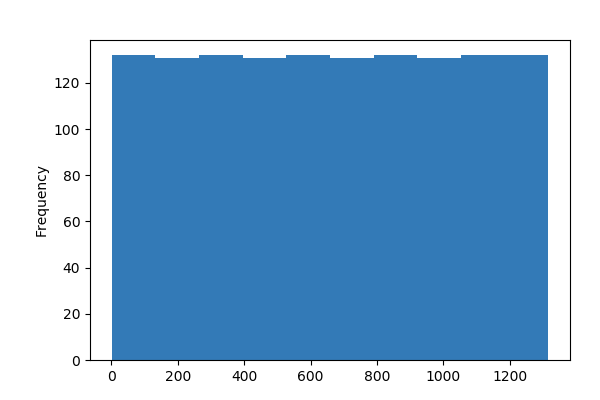

**Common Values**

| Value | Count | Frequency (%) |  |
| --- | --- | --- | --- |
| 1316 | 1 | 0.1% |  |
| 432 | 1 | 0.1% |  |
| 434 | 1 | 0.1% |  |
| 435 | 1 | 0.1% |  |
| 436 | 1 | 0.1% |  |
| 437 | 1 | 0.1% |  |
| 438 | 1 | 0.1% |  |
| 439 | 1 | 0.1% |  |
| 440 | 1 | 0.1% |  |
| 441 | 1 | 0.1% |  |
| Other values (1306) | 1306 | 99.2% |  |

**Extreme Values**

Minimum 5 values

| Value | Count | Frequency (%) |  |
| --- | --- | --- | --- |
| 1 | 1 | 0.1% |  |
| 2 | 1 | 0.1% |  |
| 3 | 1 | 0.1% |  |
| 4 | 1 | 0.1% |  |
| 5 | 1 | 0.1% |  |

Maximum 5 values

| Value | Count | Frequency (%) |  |
| --- | --- | --- | --- |
| 1312 | 1 | 0.1% |  |
| 1313 | 1 | 0.1% |  |
| 1314 | 1 | 0.1% |  |
| 1315 | 1 | 0.1% |  |
| 1316 | 1 | 0.1% |  |

age  
Categorical

| Distinct count | 2 |
| --- | --- |
| Unique (%) | 0.2% |
| Missing (%) | 0.0% |
| Missing (n) | 0 |

| adults | 1207 |
| --- | --- |
| child | 109 |

Toggle details

| Value | Count | Frequency (%) |  |
| --- | --- | --- | --- |
| adults | 1207 | 91.7% |  |
| child | 109 | 8.3% |  |

class  
Categorical

| Distinct count | 3 |
| --- | --- |
| Unique (%) | 0.2% |
| Missing (%) | 0.0% |
| Missing (n) | 0 |

| 3rd class | 706 |
| --- | --- |
| 1st class | 325 |
| 2nd class | 285 |

Toggle details

| Value | Count | Frequency (%) |  |
| --- | --- | --- | --- |
| 3rd class | 706 | 53.6% |  |
| 1st class | 325 | 24.7% |  |
| 2nd class | 285 | 21.7% |  |

sex  
Categorical

| Distinct count | 2 |
| --- | --- |
| Unique (%) | 0.2% |
| Missing (%) | 0.0% |
| Missing (n) | 0 |

| man | 869 |
| --- | --- |
| women | 447 |

Toggle details

| Value | Count | Frequency (%) |  |
| --- | --- | --- | --- |
| man | 869 | 66.0% |  |
| women | 447 | 34.0% |  |

survived  
Categorical

| Distinct count | 2 |
| --- | --- |
| Unique (%) | 0.2% |
| Missing (%) | 0.0% |
| Missing (n) | 0 |

| no | 817 |
| --- | --- |
| yes | 499 |

Toggle details

| Value | Count | Frequency (%) |  |
| --- | --- | --- | --- |
| no | 817 | 62.1% |  |
| yes | 499 | 37.9% |  |

Correlations

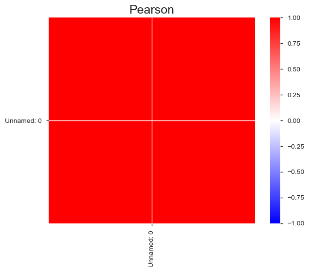

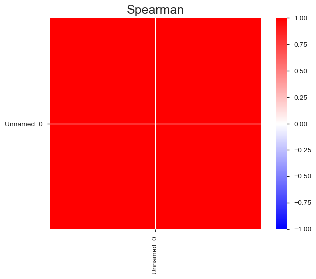

Sample

|  | Unnamed: 0 | class | age | sex | survived |
| --- | --- | --- | --- | --- | --- |
| 0 | 1 | 1st class | adults | man | yes |
| 1 | 2 | 1st class | adults | man | yes |
| 2 | 3 | 1st class | adults | man | yes |
| 3 | 4 | 1st class | adults | man | yes |
| 4 | 5 | 1st class | adults | man | yes |

```python
pandas_profiling.ProfileReport(df)
```

**Categorizar Variables**

[output not shown]

Como hay un mayor numero de adultos que de niños esto podria afectar los valores se aconseja mirar esta relaciones entre ambos para determinar como esto afecta los resultados o si no afectan.

```python
X = df[['age','class','sex']]
y = df['survived']
X_train, X_test, y_train, y_test = train_test_split(X, y, test_size=0.2, random_state=0)
train = pd.DataFrame()
```

```python
train['age'] = X_train['age'].values
train['sex'] = X_train['sex'].values
train['class'] = X_train['class'].values
train['survived'] = y_train.values
print(train.head())
```

```
      age    sex      class survived
0   child    man  3rd class       no
1  adults    man  2nd class       no
2  adults    man  3rd class       no
3  adults  women  3rd class      yes
4  adults  women  3rd class      yes
```

```python
arbol3=Tree.from_pandas_df(df, dict(zip(independent_variable_columns, ['nominal'] * 3)), dep_variable).to_tree()
```

```python
arbol3.show()
```

```
([], {'no': 817.0, 'yes': 499.0}, (sex, p=1.0659916015697211e-76, score=343.5683748952206, groups=[['man'], ['women']]), dof=1))
├── (['man'], {'no': 694.0, 'yes': 175.0}, (class, p=7.65402627362462e-08, score=28.891698180661038, groups=[['1st class'], ['2nd class', '3rd class']]), dof=1))
│   ├── (['1st class'], {'no': 118.0, 'yes': 62.0}, <Invalid Chaid Split> - the max depth has been reached)
│   └── (['2nd class', '3rd class'], {'no': 576.0, 'yes': 113.0}, <Invalid Chaid Split> - the max depth has been reached)
└── (['women'], {'no': 123.0, 'yes': 324.0}, (class, p=3.799847801639209e-28, score=126.27484318020652, groups=[['1st class'], ['2nd class'], ['3rd class']]), dof=2))
    ├── (['1st class'], {'no': 4.0, 'yes': 141.0}, <Invalid Chaid Split> - the max depth has been reached)
    ├── (['2nd class'], {'no': 13.0, 'yes': 93.0}, <Invalid Chaid Split> - the max depth has been reached)
    └── (['3rd class'], {'no': 106.0, 'yes': 90.0}, <Invalid Chaid Split> - the max depth has been reached)
```

```python
#man or women. En man va de que clase es, 2 y 3 estan como iguales. Ahora de women pasa lo mismo.
values_test = X_test.values
y_pred = []
for i in range(0,len(values_test)):
    v = values_test[i]
    if(v[2] == 'man'):
        if(v[1]== '1st class'):
            y_pred.append('no')
        else:
            y_pred.append('no')
    else:
        if(v[1] == '1st class'):
            y_pred.append('yes')
        elif(v[1]== '2nd class'):
            y_pred.append('yes')
        else:
            y_pred.append('no')
```

```python
y_test2 = y_test.values
from sklearn.metrics import precision_recall_fscore_support
precision_recall_fscore_support(y_test2, y_pred, average='macro')
```

```
(0.849537037037037, 0.7193173565722585, 0.7299470899470899, None)
```